# Zadania7

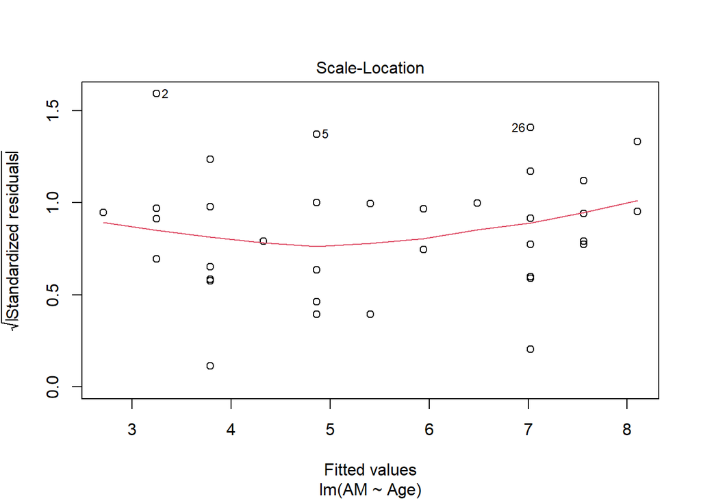

```r
plot(reg2,3)
```

```r
summary(reg3)
```

```
##
## Call:
## lm(formula = AM ~ BM + Age, data = deer)
##
## Residuals:
##      Min       1Q   Median       3Q      Max
## -1.61259 -0.65823  0.03031  0.47299  2.50169
##
## Coefficients:
##              Estimate Std. Error t value Pr(>|t|)
## (Intercept) -2.009266   1.010621  -1.988  0.05541 .
## BM           0.025870   0.007583   3.411  0.00177 **
## Age          0.421773   0.061560   6.851 9.46e-08 ***
## ---
## Signif. codes:  0 '***' 0.001 '**' 0.01 '*' 0.05 '.' 0.1 ' ' 1
##
## Residual standard error: 0.9316 on 32 degrees of freedom
## Multiple R-squared:  0.7946, Adjusted R-squared:  0.7818
## F-statistic:  61.9 on 2 and 32 DF,  p-value: 1.003e-11
```

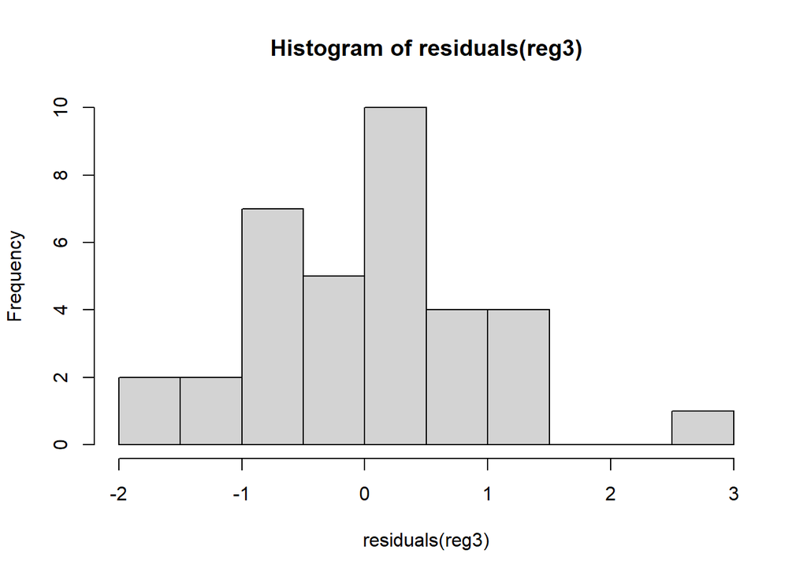

```r
hist(residuals(reg3))
```

**Założenia:**  
Warunki przeprowadzenia testów zostały spełnione, wartości rozmieszczone są symetrycznie wokół zera oraz rozkład resztowy jest zgodny z normalnym. Także dystans Cooka jest mniejszy niż 100, a więc outlayery nie mają wpływu na ostateczny wynik.

```r
confint(reg3)
```

```
##                   2.5 %     97.5 %
## (Intercept) -4.06783360 0.04930207
## BM           0.01042306 0.04131643
## Age          0.29637979 0.54716594
```

Model jest istotny statystycznie.

**Wykres wynikowy:**

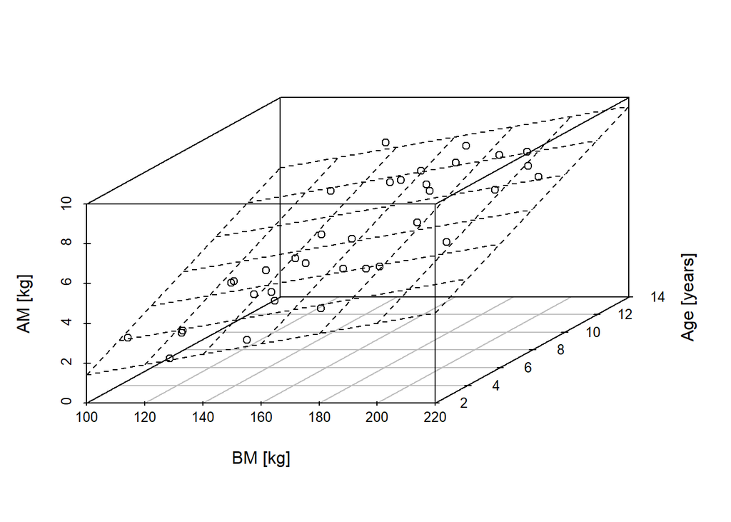

```r
splot <- scatterplot3d(x = deer$BM, y = deer$Age, z = deer$AM, angle=40, xlab="BM [kg]", ylab="Age [years]", zlab="AM [kg]")
splot$plane3d(reg3)
```

**Wnioski:**  
Wartość parametru R kwadrat wskazuje, że odpowiednio 49, 72 i 79% procent wariancji jest wyjaśnione przez model. Wysokie wartości t-value i niskie wartości p-value dla współczynnika wskazują, że test jest istotny statystycznie.

Równanie dla 3 modelu:  
Y = −2.009266 + 0.025870∗X1 + 0.421773∗X2.  
Po podstawieniu do wzoru 180kg i 8lat:  
Y = −2.009266 + 0.025870∗180 + 0.421773∗8 = **6.02151** [kg] (masa poroża).